# Final

# Calculating mean targeted and actual productivity for each day of each department and visualizing the data with line graphs.

```r
gar <- data.frame(garmentpro %>%
                    group_by(date) %>%
                    filter(department == "sewing") %>%
                    summarise(mean_tar = mean(targeted_productivity), mean_act = mean(actual_productivity)))
gar1 <- data.frame(garmentpro %>%
                    group_by(date) %>%
                    filter(department == "finishing") %>%
                    summarise(mean_tar = mean(targeted_productivity), mean_act = mean(actual_productivity)))

head(gar)
```

```
##         date  mean_tar  mean_act
## 1 2015-01-01 0.7625000 0.7550950
## 2 2015-01-03 0.7750000 0.7783303
## 3 2015-01-04 0.7750000 0.7863533
## 4 2015-01-05 0.7750000 0.7794854
## 5 2015-01-06 0.7791667 0.7877941
## 6 2015-01-07 0.7875000 0.7721603
```

```r
head(gar1)
```

```
##         date  mean_tar  mean_act
## 1 2015-01-01 0.7357143 0.6563373
## 2 2015-01-03 0.7777778 0.8353641
## 3 2015-01-04 0.7777778 0.7719357
## 4 2015-01-05 0.7700000 0.8158773
## 5 2015-01-06 0.7888889 0.8291261
## 6 2015-01-07 0.7800000 0.7590747
```

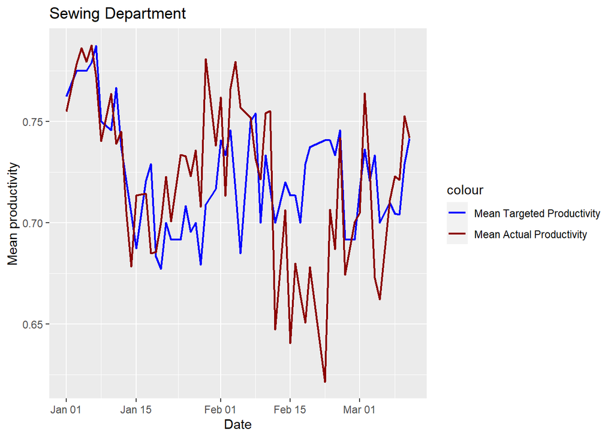

```r
colors <- c("Mean Targeted Productivity" = "blue", "Mean Actual Productivity" = "darkred")

ggplot(gar, aes(x=date)) +
  geom_line(aes(y = mean_tar, color = "Mean Targeted Productivity"), group = 1, lwd = 0.75) +
  geom_line(aes(y = mean_act, color="Mean Actual Productivity"), group = 1, lwd = 0.75) +
  labs(x = "Date", y = "Mean productivity")+
  scale_color_manual(values = colors) +
  ggtitle("Sewing Department")
```

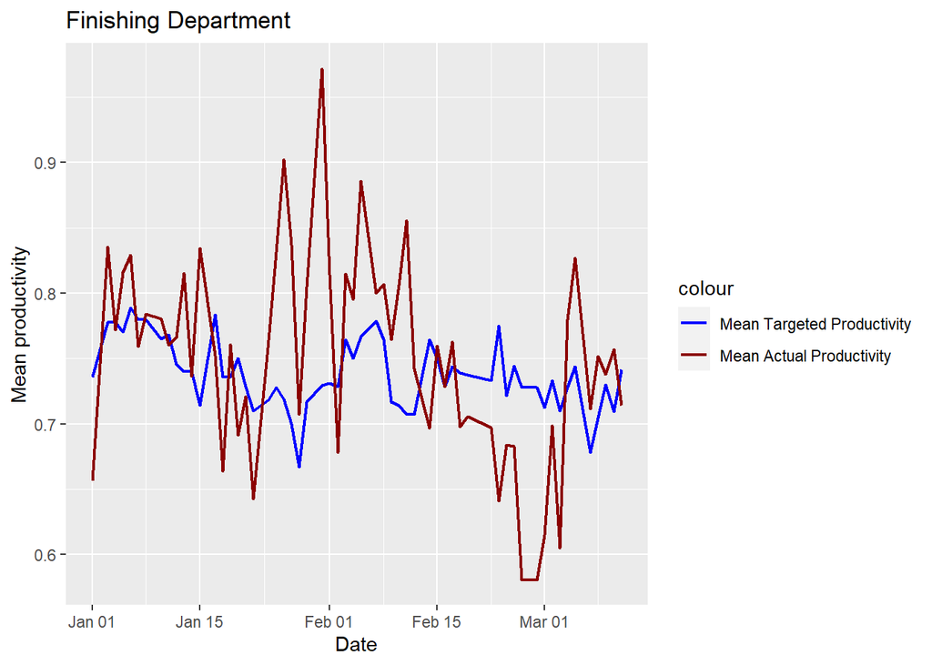

```r
ggplot(gar1, aes(x=date)) +
  geom_line(aes(y = mean_tar, color = "Mean Targeted Productivity"), group = 1, lwd = 0.75) +
  geom_line(aes(y = mean_act, color="Mean Actual Productivity"), group = 1, lwd = 0.75) +
  labs(x = "Date", y = "Mean productivity")+
  scale_color_manual(values = colors)+
  ggtitle("Finishing Department")
```

```r
sewing <- data.frame(garmentpro %>%

                       filter(department == "sewing"))

finishing <- data.frame(garmentpro %>%
                          filter(department == "finishing"))
```

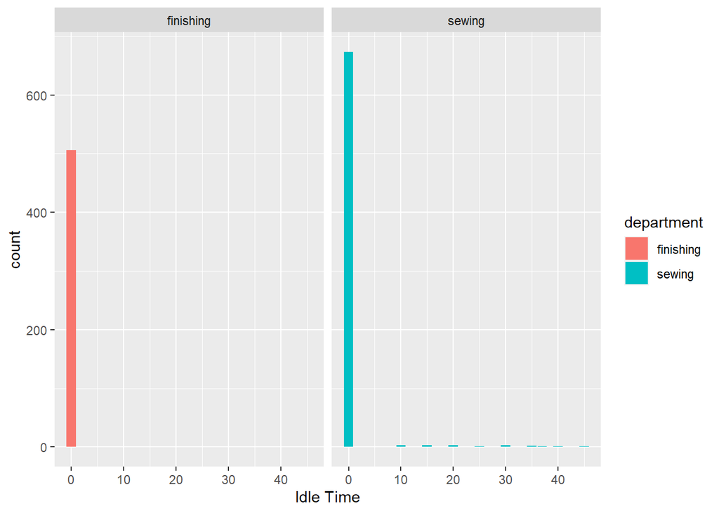

```r
ggplot(garmentpro, aes(x=idle_men, fill=department))+
  geom_bar() + facet_grid(.~department) + xlab("Idle Time")
```

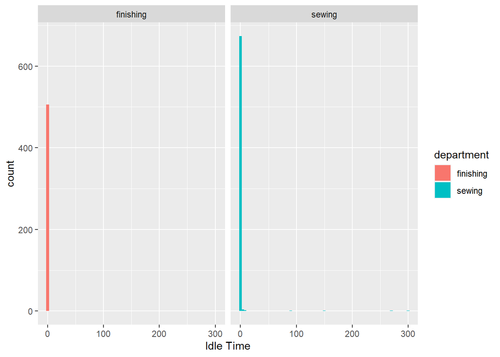

```r
ggplot(garmentpro, aes(x=idle_time, fill=department))+
  geom_bar(width = 5) + facet_grid(.~department) + xlab("Idle Time")
```

The graphs above shows that the variables ‘idle-men’ and ‘idle_time’ consists ‘0’ as their values so these two variables would not be used in Multiple Linear Regression.

# Multiple Linear Regression for Sewing

```r
fit = lm(difference ~ quarter + day + smv + wip + over_time + incentive + no_of_style_change + no_of_workers, data = sewing)

summary(fit)
```

```
##
## Call:
## lm(formula = difference ~ quarter + day + smv + wip + over_time +
##     incentive + no_of_style_change + no_of_workers, data = sewing)
##
## Residuals:
##      Min       1Q   Median       3Q      Max
## -0.34633 -0.02672  0.00313  0.03716  0.56631
##
## Coefficients:
##                      Estimate Std. Error t value Pr(>|t|)
## (Intercept)        -1.195e-01  1.963e-02  -6.085 1.96e-09 ***
## quarterQuarter2     3.395e-06  8.254e-03   0.000   0.9997
## quarterQuarter3    -8.130e-03  9.287e-03  -0.875   0.3817
## quarterQuarter4    -5.995e-03  9.403e-03  -0.638   0.5240
## quarterQuarter5    -3.946e-03  1.823e-02  -0.216   0.8287
## daySaturday        -6.542e-03  1.127e-02  -0.581   0.5617
## daySunday          -2.035e-02  1.067e-02  -1.907   0.0569 .
## dayThursday        -7.483e-03  1.084e-02  -0.691   0.4901
## dayTuesday         -5.834e-03  1.064e-02  -0.548   0.5835
## dayWednesday       -1.061e-02  1.063e-02  -0.998   0.3186
## smv                -3.576e-03  5.443e-04  -6.569 1.01e-10 ***
## wip                -1.546e-07  1.749e-06  -0.088   0.9296
## over_time           3.611e-07  1.227e-06   0.294   0.7687
## incentive           2.649e-03  1.223e-04  21.653  < 2e-16 ***
## no_of_style_change  1.305e-02  6.898e-03   1.891   0.0590 .
## no_of_workers       1.689e-03  4.262e-04   3.962 8.23e-05 ***
## ---
## Signif. codes:  0 '***' 0.001 '**' 0.01 '*' 0.05 '.' 0.1 ' ' 1
##
## Residual standard error: 0.07974 on 675 degrees of freedom
## Multiple R-squared:  0.4952, Adjusted R-squared:  0.484
## F-statistic: 44.14 on 15 and 675 DF,  p-value: < 2.2e-16
```

Eliminating quarter

```r
fit = lm(difference ~ day+smv + wip + over_time + incentive + no_of_style_change + no_of_workers, data = sewing)

summary(fit)
```

```
##
## Call:
## lm(formula = difference ~ day + smv + wip + over_time + incentive +
##     no_of_style_change + no_of_workers, data = sewing)
##
## Residuals:
##      Min       1Q   Median       3Q      Max
## -0.34635 -0.02519  0.00216  0.03641  0.56884
##
## Coefficients:
##                      Estimate Std. Error t value Pr(>|t|)
## (Intercept)        -1.220e-01  1.894e-02  -6.442 2.23e-10 ***
## daySaturday        -6.373e-03  1.099e-02  -0.580   0.5622
## daySunday          -2.034e-02  1.064e-02  -1.911   0.0565 .
## dayThursday        -7.721e-03  1.064e-02  -0.726   0.4682
## dayTuesday         -5.718e-03  1.061e-02  -0.539   0.5901
## dayWednesday       -1.060e-02  1.060e-02  -1.000   0.3176
## smv                -3.564e-03  5.427e-04  -6.567 1.02e-10 ***
## wip                -8.039e-08  1.727e-06  -0.047   0.9629
## over_time           1.826e-07  1.198e-06   0.152   0.8789
## incentive           2.649e-03  1.206e-04  21.968  < 2e-16 ***
## no_of_style_change  1.117e-02  6.364e-03   1.755   0.0798 .
## no_of_workers       1.708e-03  4.234e-04   4.035 6.09e-05 ***
## ---
## Signif. codes:  0 '***' 0.001 '**' 0.01 '*' 0.05 '.' 0.1 ' ' 1
##
## Residual standard error: 0.07958 on 679 degrees of freedom
## Multiple R-squared:  0.4943, Adjusted R-squared:  0.4861
## F-statistic: 60.34 on 11 and 679 DF,  p-value: < 2.2e-16
```

Eliminating wip

```r
fit = lm(difference ~ day++ smv + over_time + incentive + no_of_style_change + no_of_workers, data = sewing)

summary(fit)
```

```
##
## Call:
## lm(formula = difference ~ day + +smv + over_time + incentive +
##     no_of_style_change + no_of_workers, data = sewing)
##
## Residuals:
##      Min       1Q   Median       3Q      Max
## -0.34634 -0.02517  0.00217  0.03642  0.56876
##
## Coefficients:
##                      Estimate Std. Error t value Pr(>|t|)
## (Intercept)        -1.222e-01  1.875e-02  -6.516 1.41e-10 ***
## daySaturday        -6.276e-03  1.078e-02  -0.582   0.5608
## daySunday          -2.025e-02  1.046e-02  -1.936   0.0532 .
## dayThursday        -7.625e-03  1.043e-02  -0.731   0.4649
## dayTuesday         -5.624e-03  1.041e-02  -0.540   0.5891
## dayWednesday       -1.051e-02  1.039e-02  -1.011   0.3122
## smv                -3.563e-03  5.419e-04  -6.575 9.68e-11 ***
## over_time           1.824e-07  1.197e-06   0.152   0.8790
## incentive           2.648e-03  1.191e-04  22.240  < 2e-16 ***
## no_of_style_change  1.117e-02  6.359e-03   1.757   0.0794 .
## no_of_workers       1.708e-03  4.228e-04   4.039 5.99e-05 ***
## ---
## Signif. codes:  0 '***' 0.001 '**' 0.01 '*' 0.05 '.' 0.1 ' ' 1
##
## Residual standard error: 0.07952 on 680 degrees of freedom
## Multiple R-squared:  0.4943, Adjusted R-squared:  0.4869
## F-statistic: 66.47 on 10 and 680 DF,  p-value: < 2.2e-16
```

Eliminating over_time

```r
fit = lm(difference ~ day++ smv + incentive + no_of_style_change + no_of_workers, data = sewing)

summary(fit)
```

```
##
## Call:
## lm(formula = difference ~ day + +smv + incentive + no_of_style_change +
##     no_of_workers, data = sewing)
##
## Residuals:
##      Min       1Q   Median       3Q      Max
## -0.34677 -0.02501  0.00195  0.03664  0.56858
##
## Coefficients:
##                      Estimate Std. Error t value Pr(>|t|)
## (Intercept)        -0.1220741  0.0187268  -6.519 1.38e-10 ***
## daySaturday        -0.0061629  0.0107510  -0.573   0.5667
## daySunday          -0.0201950  0.0104427  -1.934   0.0535 .
## dayThursday        -0.0075182  0.0103960  -0.723   0.4698
## dayTuesday         -0.0056216  0.0103989  -0.541   0.5890
## dayWednesday       -0.0105596  0.0103763  -1.018   0.3092
## smv                -0.0035560  0.0005395  -6.592 8.71e-11 ***
## incentive           0.0026476  0.0001190  22.255  < 2e-16 ***
## no_of_style_change  0.0108864  0.0060701   1.793   0.0733 .
## no_of_workers       0.0017263  0.0004043   4.270 2.24e-05 ***
## ---
## Signif. codes:  0 '***' 0.001 '**' 0.01 '*' 0.05 '.' 0.1 ' ' 1
##
## Residual standard error: 0.07946 on 681 degrees of freedom
## Multiple R-squared:  0.4943, Adjusted R-squared:  0.4876
## F-statistic: 73.96 on 9 and 681 DF,  p-value: < 2.2e-16
```

Eliminating day

```r
fit = lm(difference ~ smv + incentive + no_of_style_change + no_of_workers, data = sewing)

summary(fit)
```

```
##
## Call:
## lm(formula = difference ~ smv + incentive + no_of_style_change +
##     no_of_workers, data = sewing)
##
## Residuals:
##      Min       1Q   Median       3Q      Max
## -0.35805 -0.02599  0.00210  0.03584  0.56982
##
## Coefficients:
##                      Estimate Std. Error t value Pr(>|t|)
## (Intercept)        -0.1305131  0.0175015  -7.457 2.68e-13 ***
## smv                -0.0035865  0.0005387  -6.658 5.69e-11 ***
## incentive           0.0026538  0.0001185  22.390  < 2e-16 ***
## no_of_style_change  0.0113087  0.0060520   1.869   0.0621 .
## no_of_workers       0.0017336  0.0004039   4.292 2.02e-05 ***
## ---
## Signif. codes:  0 '***' 0.001 '**' 0.01 '*' 0.05 '.' 0.1 ' ' 1
##
## Residual standard error: 0.07941 on 686 degrees of freedom
## Multiple R-squared:  0.4912, Adjusted R-squared:  0.4882
## F-statistic: 165.6 on 4 and 686 DF,  p-value: < 2.2e-16
```

Eliminating no_of_style_change

```r
fit = lm(difference ~ smv + incentive + no_of_workers, data = sewing)

summary(fit)
```

```
##
## Call:
## lm(formula = difference ~ smv + incentive + no_of_workers, data = sewing)
##
## Residuals:
##      Min       1Q   Median       3Q      Max
## -0.36510 -0.02386  0.00212  0.03515  0.56287
##
## Coefficients:
##                 Estimate Std. Error t value Pr(>|t|)
## (Intercept)   -0.1300951  0.0175317  -7.421 3.46e-13 ***
## smv           -0.0036105  0.0005395  -6.692 4.57e-11 ***
## incentive      0.0025787  0.0001117  23.085  < 2e-16 ***
## no_of_workers  0.0018562  0.0003993   4.649 4.00e-06 ***
## ---
## Signif. codes:  0 '***' 0.001 '**' 0.01 '*' 0.05 '.' 0.1 ' ' 1
##
## Residual standard error: 0.07956 on 687 degrees of freedom
## Multiple R-squared:  0.4886, Adjusted R-squared:  0.4864
## F-statistic: 218.8 on 3 and 687 DF,  p-value: < 2.2e-16
```

The variables left are Standard Minute value (smv), Incentive and No_of_workers. There are variables that have significant effect on the variation of response variable ‘difference’.

# Multiple Linear Regression for finishing

```r
fit = lm(difference ~ quarter + day + smv + wip + over_time + incentive + no_of_style_change + no_of_workers, data = finishing)

summary(fit)
```

```
##
## Call:
## lm(formula = difference ~ quarter + day + smv + wip + over_time +
##     incentive + no_of_style_change + no_of_workers, data = finishing)
##
## Residuals:
##      Min       1Q   Median       3Q      Max
## -0.63806 -0.09944  0.01429  0.12232  0.61824
##
## Coefficients: (2 not defined because of singularities)
##                      Estimate Std. Error t value Pr(>|t|)
## (Intercept)        -3.899e-01  6.376e-02  -6.116 1.96e-09 ***
## quarterQuarter2     2.258e-02  2.305e-02   0.980 0.327813
## quarterQuarter3    -2.315e-02  2.703e-02  -0.856 0.392174
## quarterQuarter4    -2.275e-02  2.477e-02  -0.918 0.358887
## quarterQuarter5     1.833e-01  4.788e-02   3.829 0.000145 ***
## daySaturday         7.998e-03  3.167e-02   0.253 0.800755
## daySunday           5.366e-03  3.057e-02   0.176 0.860728
## dayThursday        -1.148e-02  3.226e-02  -0.356 0.722145
## dayTuesday          2.378e-02  3.090e-02   0.770 0.441944
## dayWednesday       -1.770e-03  3.040e-02  -0.058 0.953590
## smv                 6.277e-02  1.501e-02   4.181 3.44e-05 ***
## wip                        NA         NA      NA       NA
## over_time          -1.912e-05  6.722e-06  -2.844 0.004634 **
## incentive          -5.392e-06  3.798e-05  -0.142 0.887157
## no_of_style_change         NA         NA      NA       NA
## no_of_workers       1.841e-02  2.844e-03   6.474 2.32e-10 ***
## ---
## Signif. codes:  0 '***' 0.001 '**' 0.01 '*' 0.05 '.' 0.1 ' ' 1
##
## Residual standard error: 0.1941 on 492 degrees of freedom
## Multiple R-squared:  0.1597, Adjusted R-squared:  0.1375
## F-statistic: 7.193 on 13 and 492 DF,  p-value: 6.357e-13
```

Eliminating wip and no_of_style_change

```r
fit = lm(difference ~ quarter + day + smv + over_time + incentive + no_of_workers, data = finishing)

summary(fit)
```

```
##
## Call:
## lm(formula = difference ~ quarter + day + smv + over_time + incentive +
##     no_of_workers, data = finishing)
##
## Residuals:
##      Min       1Q   Median       3Q      Max
## -0.63806 -0.09944  0.01429  0.12232  0.61824
##
## Coefficients:
##                   Estimate Std. Error t value Pr(>|t|)
## (Intercept)     -3.899e-01  6.376e-02  -6.116 1.96e-09 ***
## quarterQuarter2  2.258e-02  2.305e-02   0.980 0.327813
## quarterQuarter3 -2.315e-02  2.703e-02  -0.856 0.392174
## quarterQuarter4 -2.275e-02  2.477e-02  -0.918 0.358887
## quarterQuarter5  1.833e-01  4.788e-02   3.829 0.000145 ***
## daySaturday      7.998e-03  3.167e-02   0.253 0.800755
## daySunday        5.366e-03  3.057e-02   0.176 0.860728
## dayThursday     -1.148e-02  3.226e-02  -0.356 0.722145
## dayTuesday       2.378e-02  3.090e-02   0.770 0.441944
## dayWednesday    -1.770e-03  3.040e-02  -0.058 0.953590
## smv              6.277e-02  1.501e-02   4.181 3.44e-05 ***
## over_time       -1.912e-05  6.722e-06  -2.844 0.004634 **
## incentive       -5.392e-06  3.798e-05  -0.142 0.887157
## no_of_workers    1.841e-02  2.844e-03   6.474 2.32e-10 ***
## ---
## Signif. codes:  0 '***' 0.001 '**' 0.01 '*' 0.05 '.' 0.1 ' ' 1
##
## Residual standard error: 0.1941 on 492 degrees of freedom
## Multiple R-squared:  0.1597, Adjusted R-squared:  0.1375
## F-statistic: 7.193 on 13 and 492 DF,  p-value: 6.357e-13
```

Eliminating day

```r
fit = lm(difference ~ quarter + smv + over_time + incentive + no_of_workers, data = finishing)

summary(fit)
```

```
##
## Call:
## lm(formula = difference ~ quarter + smv + over_time + incentive +
##     no_of_workers, data = finishing)
##
## Residuals:
##      Min       1Q   Median       3Q      Max
## -0.63653 -0.09789  0.01263  0.12270  0.61118
##
## Coefficients:
##                   Estimate Std. Error t value Pr(>|t|)
## (Intercept)     -3.853e-01  5.997e-02  -6.424 3.11e-10 ***
## quarterQuarter2  2.283e-02  2.290e-02   0.997 0.319305
## quarterQuarter3 -2.492e-02  2.686e-02  -0.928 0.354102
## quarterQuarter4 -2.282e-02  2.468e-02  -0.925 0.355439
## quarterQuarter5  1.777e-01  4.538e-02   3.916 0.000103 ***
## smv              6.286e-02  1.493e-02   4.211 3.02e-05 ***
## over_time       -2.023e-05  6.461e-06  -3.131 0.001843 **
## incentive       -8.850e-06  3.649e-05  -0.243 0.808459
## no_of_workers    1.857e-02  2.818e-03   6.591 1.12e-10 ***
## ---
## Signif. codes:  0 '***' 0.001 '**' 0.01 '*' 0.05 '.' 0.1 ' ' 1
##
## Residual standard error: 0.1934 on 497 degrees of freedom
## Multiple R-squared:  0.1572, Adjusted R-squared:  0.1436
## F-statistic: 11.59 on 8 and 497 DF,  p-value: 3.803e-15
```

Eliminating incentive

```r
fit = lm(difference ~ quarter + smv + over_time + no_of_workers, data = finishing)

summary(fit)
```

```
##
## Call:
## lm(formula = difference ~ quarter + smv + over_time + no_of_workers,
##     data = finishing)
##
## Residuals:
##      Min       1Q   Median       3Q      Max
## -0.63576 -0.09779  0.01185  0.12283  0.61192
##
## Coefficients:
##                   Estimate Std. Error t value Pr(>|t|)
## (Intercept)     -3.853e-01  5.991e-02  -6.431 2.98e-10 ***
## quarterQuarter2  2.200e-02  2.263e-02   0.972   0.3313
## quarterQuarter3 -2.491e-02  2.684e-02  -0.928   0.3538
## quarterQuarter4 -2.294e-02  2.465e-02  -0.931   0.3524
## quarterQuarter5  1.778e-01  4.534e-02   3.922   0.0001 ***
## smv              6.299e-02  1.490e-02   4.227 2.82e-05 ***
## over_time       -1.996e-05  6.362e-06  -3.138   0.0018 **
## no_of_workers    1.847e-02  2.787e-03   6.630 8.75e-11 ***
## ---
## Signif. codes:  0 '***' 0.001 '**' 0.01 '*' 0.05 '.' 0.1 ' ' 1
##
## Residual standard error: 0.1932 on 498 degrees of freedom
## Multiple R-squared:  0.1571, Adjusted R-squared:  0.1452
## F-statistic: 13.26 on 7 and 498 DF,  p-value: 1.024e-15
```

Eliminating quarter

```r
fit = lm(difference ~ smv + over_time + no_of_workers, data = finishing)

summary(fit)
```

```
##
## Call:
## lm(formula = difference ~ smv + over_time + no_of_workers, data = finishing)
##
## Residuals:
##      Min       1Q   Median       3Q      Max
## -0.66259 -0.10892  0.01452  0.12889  0.58184
##
## Coefficients:
##                 Estimate Std. Error t value Pr(>|t|)
## (Intercept)   -3.643e-01  5.937e-02  -6.136 1.72e-09 ***
## smv            6.083e-02  1.505e-02   4.043 6.12e-05 ***
## over_time     -2.363e-05  6.322e-06  -3.738 0.000207 ***
## no_of_workers  1.841e-02  2.831e-03   6.504 1.90e-10 ***
## ---
## Signif. codes:  0 '***' 0.001 '**' 0.01 '*' 0.05 '.' 0.1 ' ' 1
##
## Residual standard error: 0.1966 on 502 degrees of freedom
## Multiple R-squared:  0.1206, Adjusted R-squared:  0.1153
## F-statistic: 22.94 on 3 and 502 DF,  p-value: 6.222e-14
```

The variables left are Standard Minute value (smv), Overtime and No_of_workers. There are variables that have significant effect on the variation of response variable ‘difference’.

# Finding correlation between these significant variables that would be used to provide useful information about the forthcoming graphs in this file.

```r
cor(garmentpro[garmentpro$department == "sewing", c("no_of_workers", "difference","smv","incentive")])
```

```
##               no_of_workers  difference        smv   incentive
## no_of_workers    1.00000000  0.07744478  0.5775039  0.07958383
## difference       0.07744478  1.00000000 -0.1945210  0.67430597
## smv              0.57750386 -0.19452104  1.0000000 -0.09133990
## incentive        0.07958383  0.67430597 -0.0913399  1.00000000
```

```r
cor(garmentpro[garmentpro$department == "finishing", c("no_of_workers", "difference","smv","over_time")])
```

```
##               no_of_workers difference       smv over_time
## no_of_workers     1.0000000  0.2625248 0.2047985 0.6268904
## difference        0.2625248  1.0000000 0.2151044 0.0463541
## smv               0.2047985  0.2151044 1.0000000 0.1499879
## over_time         0.6268904  0.0463541 0.1499879 1.0000000
```

# Visualizing relationship between Number of Workers and Difference in Productivity

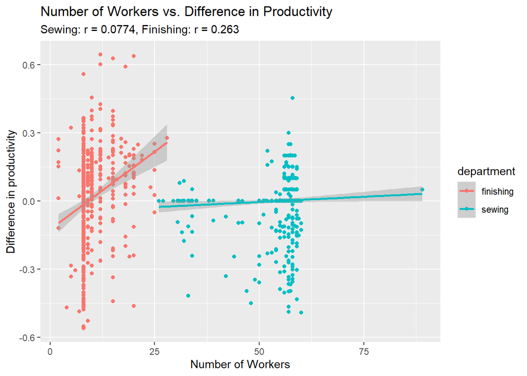

```r
ggplot(garmentpro,aes(x=no_of_workers,
             y=difference,
             color=department))+
  geom_point()+
  geom_smooth(formula = y ~ x, method = "lm")+ ggtitle("Number of Workers vs. Difference in Productivity", subtitle = "Sewing: r = 0.0774, Finishing: r = 0.263") + xlab("Number of Workers") + ylab("Difference in productivity")
```

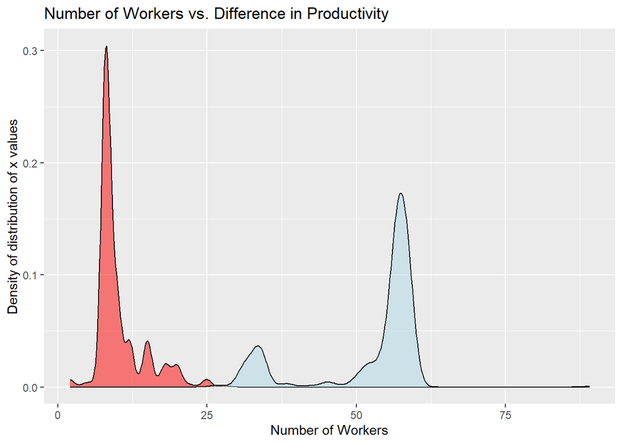

```r
xdensity <- ggplot(garmentpro, aes(x= no_of_workers, fill=department)) +
  geom_density(alpha=.5) +
  scale_fill_manual(values = c('red','lightblue')) +
  theme(legend.position = "none")+ ggtitle("Number of Workers vs. Difference in Productivity") + xlab("Number of Workers") + ylab("Density of distribution of x values")


xdensity
```

The x density curve above show that Finishing department has less number of workers in each team in comparison to that of sewing department.

# Visualizing relationship between Standard Minute Value(smv) and Difference in Productivity

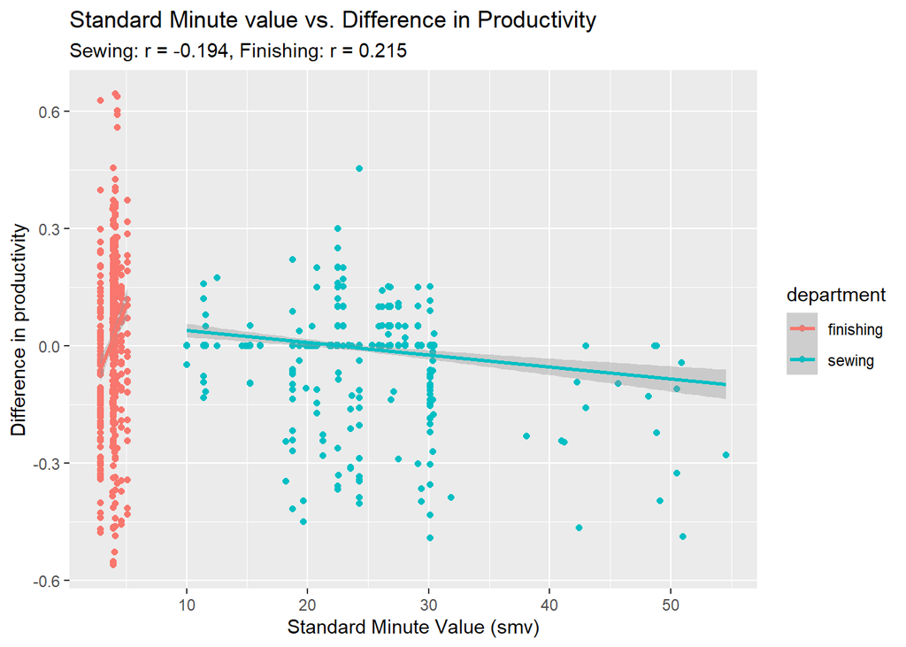

```r
ggplot(garmentpro,aes(x=smv,
             y=difference,
             color=department))+
  geom_point()+
  geom_smooth(formula = y ~ x, method = "lm") + ggtitle("Standard Minute value vs. Difference in Productivity", subtitle = "Sewing: r = -0.194, Finishing: r = 0.215") + xlab("Standard Minute Value (smv)") + ylab("Difference in productivity")
```

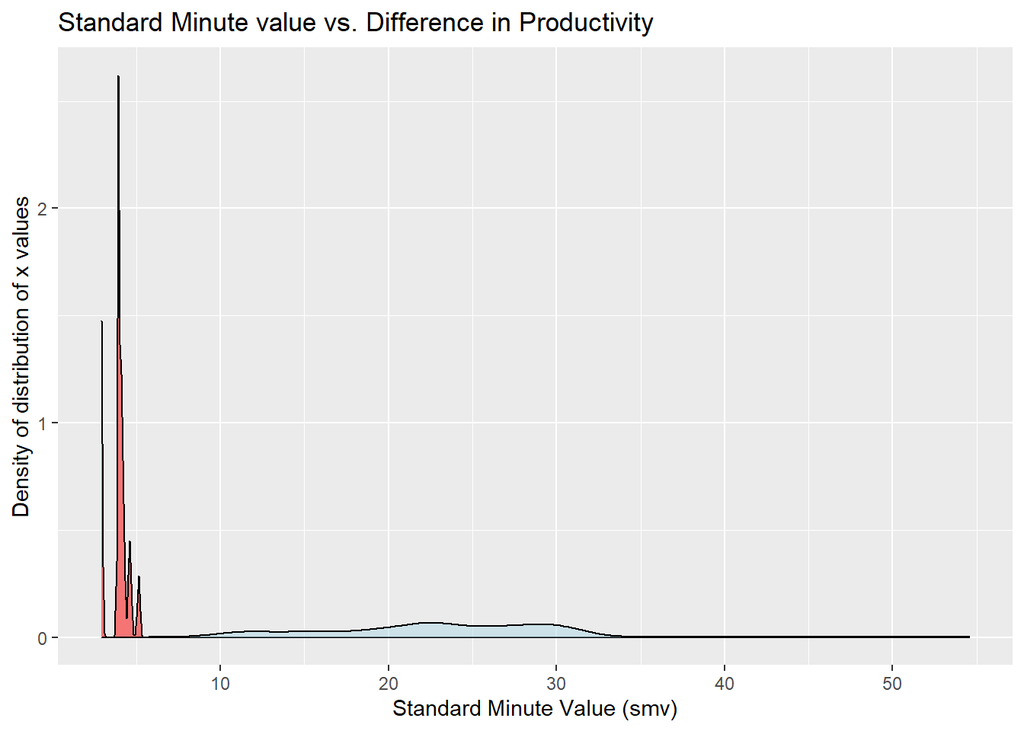

```r
xdensity <- ggplot(garmentpro, aes(x= smv, fill=department)) +
  geom_density(alpha=.5) +
  scale_fill_manual(values = c('red','lightblue')) +
  theme(legend.position = "none") + ggtitle("Standard Minute value vs. Difference in Productivity") + xlab("Standard Minute Value (smv)") + ylab("Density of distribution of x values")


xdensity
```

The x density curve above show that Finishing department has less allocated time for a task in comparison to that of sewing department.